# Regression Splines

## Regression Splines

Questo metodo per fare regressione è non parametrico e si è costruito per risolvere il problema dell’elevata collinearità presente in molti modelli polinomiali; infatti se ad esempio supponiamo:

$$y = f(x) + \varepsilon$$

Consideriamo la seguente funzione per $x$
$$f(x) = sin(2(4x-2)) + 2e^{-(16^2)(x-.5)^2}$$

Servirebbe un elevato grado (pari a 15) alla regressione polinomiale per descrivere in modo accurato la funzione ma questo comporterebbe un alta correlazione che ha come consueguenze:

- Instabilità delle stime
- Sensibilità agli outlier

L’idea che sta alla base di questo modello è quello di dividere lo spazio da analizzare in più sezioni come divisione si scelgono dei punti detti nodi (knots) attraverso un qualche criterio (solitamente i quantili) e in ogni sezione si attua una regressione.  
Utilizzando questo metodo come sopra descritto otteniamo delle funzioni a tratti (piecewise):

- Definiamo $K$ knots (internal breakpoints) nel range di valori di $x$:
  $$\min(x)<\xi_1< \ldots < \xi_K<\max(x)$$
- poi dobbiamo fittare il modello polinomiale con d gradi nei $K+1$ intervalli

$$(-\infty, \xi_{1}], (\xi_{1}, \xi_{2}], \ldots, (\xi_{K-1}, \xi_{K}], (\xi_{K}, +\infty)$$

Consideriamo quindi una funzione generale per $x$:

$$f(x) = \sum_{j=1}^{p} \beta_j b_j(x)$$
dove
$$b_j(\cdot)$$
sono funzioni note chiamate **basis functions**.

```r
set.seed(123)
x = sort(runif(500))
mu = sin(2*(4*x-2)) + 2*exp(-(16^2)*((x-.5)^2))
y = rnorm(500, mu, .3)
knots = seq(0.1, 0.9, by=.1)
xcut = cut(x, c(-Inf,knots,Inf) )
```

**Step function d=0**
$$b_1(X) = I\{x < \xi_1\}, b_2(x) = I\{\xi_1 \leq x < \xi_2\} ,\ldots, b_{K}(x) = I\{\xi_{K-1} \leq x < \xi_K\}, b_{K+1}(x) = I\{ x \geq \xi_K\}$$

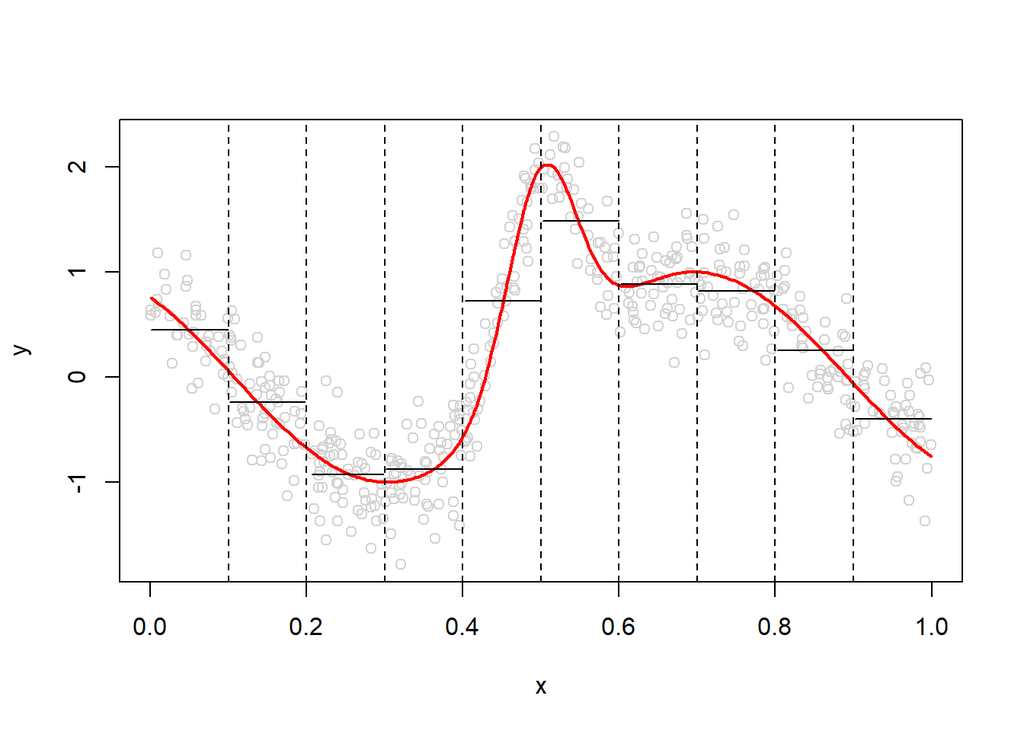

```r
plot(x,y ,col="lightgray")
lines(x, mu, col=2, lwd=2)
abline(v=knots, lty=2)
for (i in 1:length(levels(xcut)) ){
sub = (xcut==levels(xcut)[i])
lines(x[sub], fitted(lm(y[sub] ~ 1)) )
}
```

**Piecewise linear regression d=1**

$$b_1(x) =I\{x < \xi_1\},
b_2(x) = x \cdot I\{x < \xi_1\},
b_3(x) = I\{\xi_1 \leq x < \xi_2\},
b_4(x) = x \cdot I\{\xi_1 \leq x < \xi_2\},\ldots,
b_{2(K+1)}(x) = x \cdot I\{ x \geq \xi_K\}$$

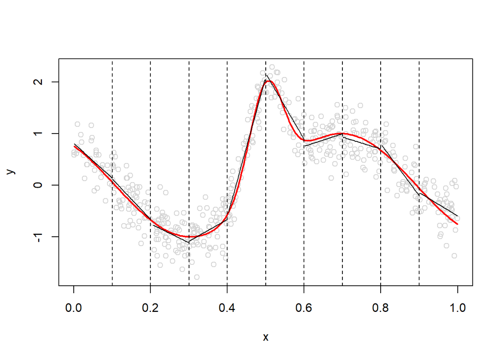

**Piecewise polynomial (cubic) regression d=3**
$$b_1(x) = 1, b_2(x)= x, b_{3}(x) = x^2, b_{4}(x) = x^3$$

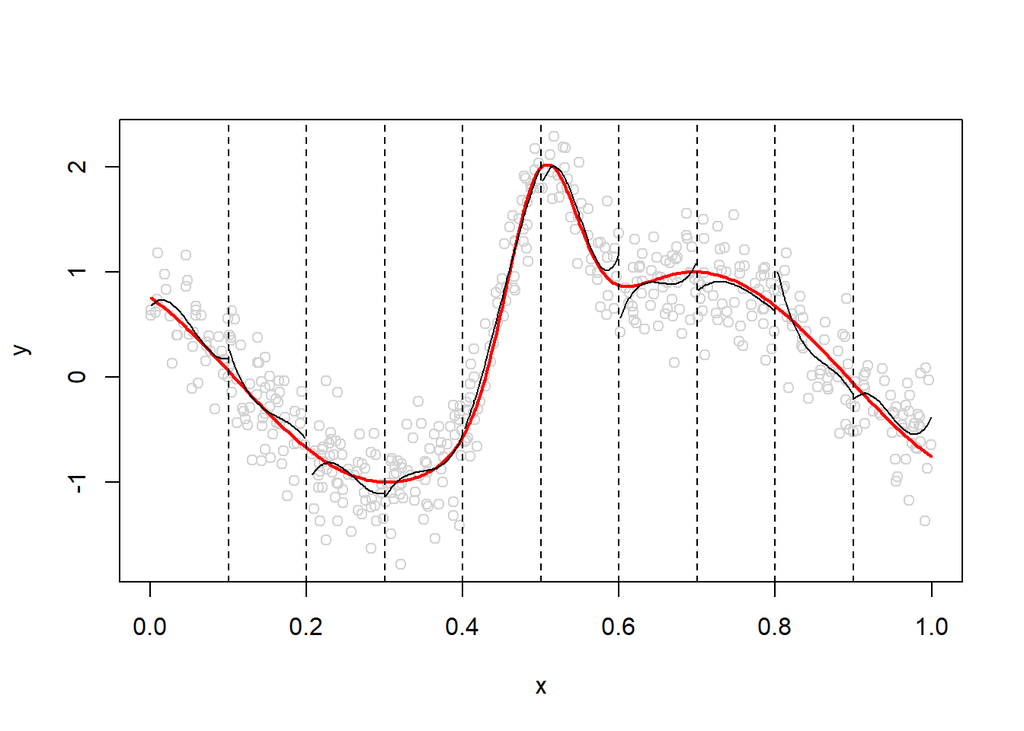

```r
plot(x,y ,col="lightgray")
lines(x, mu, col=2, lwd=2)
abline(v=knots, lty=2)
for (i in 1:length(levels(xcut)) ){
sub = (xcut==levels(xcut)[i])
lines(x[sub], fitted(lm(y[sub] ~ poly(x[sub],3))) )
}
```

In questa prima soluzione, come possiamo notare, però non è garantita la continuità. Per risolvere questo problema si è pensato di imporre che in ogni nodo la funzione abbia derivate continue dal grado 0 al grado d-1:
VINCOLI DI CONTINUITA’
$$f(\xi_i) = Y_i \ \ \ \ \ \ \ \ con \ \ \ \ \ \ \ i=1,...,K$$
$$f(\xi_i^{+}) = f(\xi_i^{-}) \ \ \ \ \ \ \ \ con \ \ \ \ \ \ \ i=2,...,Z-1$$
$$f'(\xi_i^{+}) = f'(\xi_i^{-}) \ \ \ \ \ \ \ \ con \ \ \ \ \ \ \ i=2,...,K-1$$
$$f''(\xi_i^{+}) = f''(\xi_i^{-}) \ \ \ \ \ \ \ \ con \ \ \ \ \ \ \ i=2,...,K-1$$
$$.$$
$$.$$
$$.$$

### **Trade off tra gradi e nodi**

Qui sotto c'è una applicazione che mostra come i due paratri influenzano lo sviluppo dell'algoritmo (questa applicazione è stata fatta con la versione graduita di shinyapp quindi mi scuso per eventuali disagi fornisco anche il codice .Rmd cosi da poter agevolare la visualizzazione: codice.Rmd)

[interactive chart not shown]

Questo ragionamento per quanto corretto pone due problemi:

- Oltre la derivata seconda risulta difficile valutare la continuità di una funzione.
- I parametri da stimare sono $(d+1)(K-1)$ mentre i vincoli sono soltanto $K+(d(K-d+1))$

Per quanto riguarda il primo problema si utilizza quasi universalmente un grado massimo pari a $d=3$ e si parla di *Natural cubic splines*; invece per risolvere il fatto che non si identifica una univoca funzione solitamente si impongono che le derivate seconde negli intervalli estremi siano nulle.

In definitiva la **natural cubic spline** con $K$ knots $\xi_1,\ldots,\xi_K$ è una funzione lineare a tratti $f$ che:
$f$ è un polinomio di grado 3
$$[\xi_1,\xi_2],[\xi_2,\xi_3],\ldots,[\xi_{K-1},\xi_{K}]$$
$f$ è lineare negli intervalli $(-\infty, \xi_1]$ e $[\xi_K,\infty)$
$f$, $f'$ e $f''$ sono continue in ogni nodo $\xi_1,\ldots,\xi_K$: $f(\xi_k^-)=f(\xi_k^+)$, $f'(\xi_k^-)=f'(\xi_k^+)$ e $f''(\xi_k^-)=f''(\xi_k^+)$, $k=1,\ldots,K$, dove $\xi_k^+$ e $\xi_k^-$ indicano il limite destro e sinistro della funzione $f(\cdot)$ nel nodo $\xi_k$

### **Numero di nodi**

Possiamo evitare del tutto il problema della selezione del nodo formulando un problema di minimizzazione penalizzato:

$$\underset{f \in \mathcal{F}''} \min \,\, \left\{ \sum_{i=1}^{n}(y_i - f(x_i))^2 + \lambda \int \{f''(t)\}^2 dt \right\}$$
dove $f$ si distribuisce come $\mathcal{F}''$ of funzioni due volte differenziabili

- Il primo termine è RSS, e confronta $f(x_i)$ con $y_i$ in ogni $x_i$
- Il secondo termine è una **roughness penalty (rugosità dela funzione)** e controllo come fluttua (wiggly) come si muove $f(x)$
- La penalità dipende dal **tuning parameter** $\lambda\geq 0$:
- $\lambda=0$ non impone condizione su $f$ e viene calcolata interpolando con i dati
- $\lambda = \infty$ rende la curvatura impossibili, e quindi la funzione $f$ sarà lineare

**Teorema**  
Per risolvere questo problema di minimizzazione penalizzata $f$ tra tutte le funzioni possibili di $\mathcal{F}''$ deve essere una **natural cubic spline**

- **Teorema** (Green and Silverman, 1994)

Out of all twice-differentiable functions $f$, the one that minimizes
$$\sum_{i=1}^{n}(y_i - f(x_i))^2 + \lambda \int \{f''(t)\}^2 dt$$
is a natural cubic spline with knots at every unique value of $x_i$